# Onset of Labor predictive model and patients clustering

Here we are building a model similar to the one of the OOL study but on the data of the drug assay study. The code is based on the one used for the OOL study.

## Paths

Here we set all the necessary paths to import and save data and plots.

```r
current_dir <- getwd()
my_path <- sub("/[^/]+$", "", current_dir)
setwd(paste0(my_path,"/Rscripts"))
OOL_path=paste0(my_path,"/Onset of Labor data")
drug_assay_path=paste0(my_path,"/Drug assay data")
out_path=paste0(OOL_path,"/Prediction model")
plot_path=paste0(my_path,"/Plots/Onset of Labor prediction model")
```

Creating directories for the outputs

```r
if(!file.exists(out_path)){dir.create(out_path, recursive = TRUE)}
if(!file.exists(plot_path)){dir.create(plot_path, recursive = TRUE)}
```

## Libraries

```r
library(doSNOW)
library(parallel)
library(matrixStats)
library(zoo)
library(ggVennDiagram)
library(tidyverse)
library(readxl)
library(dplyr)
library(tibble)
library(stats)
require(Metrics)
library(missMDA)
library(FactoMineR)
set.seed(2018)
```

## Importing and preprocessing data

Preprocessing function which: 1 - Remove features with proportion of NA above a certain threshold 2 - Replace remaining NA values with the median of the feature 3 - Remove features with standard deviation below a certain threshold

```r
preprocessing <- function(dataset, NA_threshold, std_threshold){
  prepro_data <- dataset
  cols <- colnames(dataset)
  # Removing columns with proportion of missing values above NA_threshold
  rm_cols <- c()
  for (col_name in cols[!cols %in% "ID"]){
    na_count <- sum(is.na(prepro_data[[col_name]]))
    if (na_count/length(prepro_data[[col_name]]) > NA_threshold){
      rm_cols[length(rm_cols)+1] <- col_name
    }
  }
  prepro_data <- prepro_data[,!colnames(prepro_data) %in% rm_cols]
  cols <- colnames(prepro_data)
  # Imputing missing values with median of the colum
  for (col_name in cols[!cols %in% "ID"]){
    median <- median(prepro_data[[col_name]], na.rm = TRUE)
    prepro_data[[col_name]][is.na(prepro_data[[col_name]])] <- median
  }
  # Removing columns with standard deviation below std_threshold
  keep_cols <- which(colSds(as.matrix(prepro_data[,-which(names(prepro_data) == "ID")]))>std_threshold)
  prepro_data <- prepro_data[,names(keep_cols)]
  return(prepro_data)
}
```

Importing and preprocessing the data for DOS between DOS_inf and DOS_sup

```r
# median.simulated.data
if (file.exists(paste0(OOL_path, "/Simulated Data/median simulated data.rda"))){
  load(paste0(OOL_path, "/Simulated Data/median simulated data.rda"))
}
# individual.simulated.data
if (file.exists(paste0(OOL_path, "/Simulated Data/individual simulated data.rda"))){
  load(paste0(OOL_path, "/Simulated Data/individual simulated data.rda"))
}
# Outcomes
Yh <- read_csv(paste0(OOL_path, "/Preprocessed Data/outcome_OOL.csv"), show_col_types = FALSE)
# CYTOF data
CYTOF <- read_csv(paste0(OOL_path, "/Preprocessed Data/immunome_EGA_pen_OOL.csv"), show_col_types = FALSE)
# Reorordering and filtering CYTOF data
data <- left_join(Yh, CYTOF, by="ID")
preterm_rows <- which(grepl(paste(c("P17_", "P8_", "P3_", "P5_", "P27_"), collapse = "|"), data$ID))
CYTOF <- dplyr::select(data, -DOS)
CYTOF <- dplyr::select(CYTOF, -EGA) # Removing EGA
Yh <- data$DOS
EGA <- data$EGA
# Preprocessing
CYTOF <- preprocessing(CYTOF, 0.2, 0.)
# Patients Id
Id <- as.factor(str_extract(data[["ID"]], "(?<=P)\\d+"))
```

## Model

Helper function for predictive modeling and LOOCV Input arguments: X: data matrix with patients, and omics measurments on rows and columns, respectively. Y: response vector. foldid: patients index that is a unique id for all subjects corresponding to the same patient. i: the patient id that should be left out during the training process parm: parameters of the Lasso Output args, ret: a list of predictions on the training and test data with the coefficients of Lasso

The complete analysis was performed using a similar strategy but using parallel processing to optimize lambda, followed by a stack generalization layer as described in the article.

```r
xxx<-function(X, Y, foldid, i, parm, predict.simulated.data=FALSE)
{
  suppressMessages(library(randomForest, quietly = TRUE))
  suppressMessages(library(glmnet, quietly = TRUE))
  set.seed(2018+123*i)

  iInd=which(foldid==unique(foldid)[i])
  if(length(iInd)<2){
    iInd=c(iInd, iInd)
  }
  if(parm$scale=='ALL'){
    X=scale(X)
  }
  if(parm$scale=='Patient')
  {
    for(ap in seq(length(unique(foldid))))
    {
      sclidx= which(foldid==unique(foldid)[ap])
      if(length(sclidx)>1)
        X[sclidx]=scale(X[sclidx], scale=F)
    }
    X=scale(X) #creates NA values for 10 features
    rm_columns <- which(colSums(is.na(X)) > 0) # Getting the columns that are removed
    original.X=X # Keeping a copy of X without any columns removed
    X=X[, complete.cases(t(X))] #we remove those features
  }
  # Calculate Spearman's rank correlation and p-value
  results <- vector("list", ncol(X))
  for (j in seq_len(ncol(X))) {
    res <- cor.test(X[, j], Y, method = "spearman", use = "pairwise.complete.obs", exact = FALSE)
    results[[j]] <- data.frame(colname = colnames(X)[j], pvalue = res$p.value)
  }

  # Combine results into a data frame
  pval_df <- bind_rows(results) %>%
                mutate(pvalue = as.numeric(pvalue))

  # Removing features with pvalue under a pval_threshold
  fiter.out.features <- pval_df[pval_df$pvalue >= parm$pval_threshold, "colname"]
  X <- X[,!(colnames(X) %in% fiter.out.features)]
  rm_columns <- c(setNames(match(fiter.out.features, colnames(original.X)), fiter.out.features), rm_columns)

  if (ncol(X) < 2){
    X=cbind(X,rep(1, nrow(X)))
  }

  XX=X[-iInd,]
  YY=Y[-iInd]
  XT=X[iInd,]
  fld=as.numeric(foldid[-iInd])

  # Transforming the values of fld so that they range from 1 to 52 (avoiding one warning from glmet)
  fld[fld>=i]=fld[fld>=i]-1

  ret = list()

  # Removed columns
  ret$rm_cols <- rm_columns

  # LASSO 1SE
  cvglm = cv.glmnet(XX, YY,  standardize=F, alpha=1, foldid = fld)
  ret$p1 = predict(cvglm, XT, s='lambda.1se')
  ret$ptrain1 = predict(cvglm, XX, s='lambda.1se')
  ret$coef = coef(cvglm, s='lambda.1se')[-1]
  ret$model = cvglm

  # Elastic Net
  EN_cv = cv.glmnet(x = XX, y = YY, standardize=F, foldid = fld, alpha = parm$a)
  ret$EN_p1 = predict(EN_cv, XT, s=EN_cv$lambda.min)
  ret$EN_ptrain1 = predict(EN_cv, XX, s=EN_cv$lambda.min)
  ret$EN_coef = coef(EN_cv, s=EN_cv$lambda.min)[-1]

  # Ridge Regression
  ridge_cv = cv.glmnet(x = XX, y = YY, standardize=F, foldid = fld, alpha = 0)
  ret$ridge_p1 = predict(ridge_cv, XT, s=ridge_cv$lambda.min)
  ret$ridge_ptrain1 = predict(ridge_cv, XX, s=ridge_cv$lambda.min)
  ret$ridge_coef = coef(ridge_cv, s=ridge_cv$lambda.min)[-1]

  # Adaptive LASSO
  alasso1_cv = cv.glmnet(x = XX, y = YY, standardize=F, foldid = fld, alpha = 1,
                        penalty.factor = 1 / abs(ret$ridge_coef),
                        keep = TRUE)
  ret$alasso_p1 = predict(alasso1_cv, XT, s=alasso1_cv$lambda.min)
  ret$alasso_ptrain1 = predict(alasso1_cv, XX, s=alasso1_cv$lambda.min)
  ret$alasso_coef = coef(alasso1_cv, s=alasso1_cv$lambda.min)[-1]

  # Random Forest
  rd_forest_cv = randomForest(x = XX, y = YY, standardize=F, importance=TRUE)
  ret$rd_forest_p1 = predict(rd_forest_cv, XT)
  ret$rd_forest_ptrain1 = predict(rd_forest_cv, XX)
  ret$rd_forest_importance = rd_forest_cv$importance

  if (predict.simulated.data){
    # Filtering the samples of the patients in the test set
    ret$median.simulated.TTL <- subset(median.simulated.data, grepl(paste0("P",unique(foldid)[i],"_"),sampleID))
    ret$individual.simulated.TTL <- subset(individual.simulated.data, grepl(paste0("P",unique(foldid)[i],"_"),sampleID))

    # Applying CYTOF preprocessing to the median simulated data
    median_prepro_data <- dplyr::select(ret$median.simulated.TTL, -c(drug, sampleID, centroid, dose)) %>%
        # Removing the columns which were removed in CYTOF
        dplyr::select(intersect(colnames(CYTOF),colnames(ret$median.simulated.TTL)), -names(ret$rm_cols)) %>%
        # Imputing the missing values with the medians of the corresponding CYTOF columns
        mutate(across(everything(), ~ ifelse(is.na(.), median(CYTOF[[cur_column()]], na.rm = TRUE), .))) %>%
        # Converting to a matrix
        as.matrix()

    # Applying CYTOF preprocessing to the individual simulated data
    individual_prepro_data <- dplyr::select(ret$individual.simulated.TTL, -c(drug, sampleID, centroid, dose)) %>%
        # Removing the columns which were removed in CYTOF
        dplyr::select(intersect(colnames(CYTOF),colnames(ret$individual.simulated.TTL)), -names(ret$rm_cols)) %>%
        # Imputing the missing values with the medians of the corresponding CYTOF columns
        mutate(across(everything(), ~ ifelse(is.na(.), median(CYTOF[[cur_column()]], na.rm = TRUE), .))) %>%
        # Converting to a matrix
        as.matrix()

    # Predictions
    if (parm$predict.model == "Random.Forest"){
      median_predictions <- predict(rd_forest_cv, median_prepro_data)
      individual_predictions <- predict(rd_forest_cv, individual_prepro_data)
    }else if(parm$predict.model == "ElasticNet"){
      median_predictions <- predict(EN_cv, median_prepro_data, s=EN_cv$lambda.min)
      individual_predictions <- predict(EN_cv, individual_prepro_data, s=EN_cv$lambda.min)
    }else if(parm$predict.model == "Lasso.1se"){
      median_predictions <- predict(cvglm, median_prepro_data, s='lambda.1se')
      individual_predictions <- predict(cvglm, individual_prepro_data, s='lambda.1se')
    }else if(parm$predict.model == "Ridge.Regression"){
      median_predictions <- predict(ridge_cv, median_prepro_data, s=ridge_cv$lambda.min)
      individual_predictions <- predict(ridge_cv, individual_prepro_data, s=ridge_cv$lambda.min)
    }else if(parm$predict.model == "Adaptive.Lasso"){
      median_predictions <- predict(alasso1_cv, median_prepro_data, s=alasso1_cv$lambda.min)
      individual_predictions <- predict(alasso1_cv, individual_prepro_data, s=alasso1_cv$lambda.min)
    }else{
      median_predictions <- rep(NA, dim(median_prepro_data)[0])
      individual_predictions <- rep(NA, dim(individual_prepro_data)[0])
    }

    ret$median.simulated.TTL <-cbind(dplyr::select(ret$median.simulated.TTL, c(drug, sampleID, centroid, dose)),
                                     median_predictions)
    ret$individual.simulated.TTL <-cbind(dplyr::select(ret$individual.simulated.TTL, c(drug, sampleID, centroid, dose)),
                                     individual_predictions)
  }

  return(ret)
}
```

Prediction of the model

```r
# Function which takes the outcome of xxx and aggregate the predictions across all the models
aggregation.of.predictions <- function(prdC){
  list_name_pred.key <- list("Lasso.1se"="p1",
                             "Ridge.Regression"="ridge_p1",
                             "ElasticNet"="EN_p1",
                             "Adaptive.Lasso"="alasso_p1",
                             "Random.Forest"="rd_forest_p1")
  list_preds <- list()
  for (model.name in names(list_name_pred.key)){
    pred.key=list_name_pred.key[[model.name]]
    ccc=vector()
    for(i in seq(npt))
    {
      iInd=which(Id==unique(Id)[i])
      if(length(iInd)>1)
      {
        ccc[iInd] = prdC[[i]][[pred.key]]
      }
      else
      {
        ccc[iInd] = prdC[[i]][[pred.key]][1]
      }
    }
    list_preds[[model.name]]=ccc
  }
  return(list_preds)
}
```

## Optimization the p-value threshold

Here we optimize the pvalue_threshold to maximize the spearmanr score of our final model

```r
######################### WARNING THIS CELL TAKES 8 HOURS TO RUN ######################################

# Range of thresholds tested
pval_thresholds=seq(1e-10, 0.7, length.out=101)

# xxx parameters
parm=list()
parm$scale='Patient'
parm$a=0.5
npt=length(unique(Id))

# Initializing the list of the spearamnr scores
listr<-c()

# Filling listr
for (pval_threshold in pval_thresholds){
  parm$pval_threshold=pval_threshold
  print(pval_threshold)
  # Opening backend-configuration
  cl <- makeSOCKcluster(detectCores())
  registerDoSNOW(cl)
  # Getting the predictions
  prdC=foreach(i=seq(npt),.packages = c("dplyr", "tibble")) %dopar% xxx(data.matrix(CYTOF), Yh, Id, i, parm, FALSE)
  # Closing backend configuration
  stopCluster(cl)
  # Getting the list of the best spearmanr score among the 5 models
  list_preds <- aggregation.of.predictions(prdC)
  # Extracting the maximum spearmanr score
  spearmr <- c()
  for (model.name in names(list_preds)){
    y_pred <- list_preds[[model.name]]
    spearmr <- c(spearmr, cor(Yh, y_pred, method = "spearman"))
  }
  # Adding the best spearmanr score to the list
  listr <- rbind(listr, c(pval_threshold, length(prdC[[1]]$rm_cols), spearmr, max(spearmr)))
}
# Renaming the columns
colnames(listr) <- c("pval_threshold", "n_rm_cols", names(list_preds), "best_r_score")
# Saving the dataframe
save(listr, file=(paste0(out_path, "/Pvalue threshold optimization.rda")))
```

Plotting the best pvalue threshold with their corresponding best spearmanr (you can look at the plot in the folder /Plots/Onset of labor prediction model)

```r
# listr
load(paste0(out_path, "/Pvalue threshold optimization.rda"))

# Reshaping listr for plotting
listr <- as.data.frame(listr) %>%
  pivot_longer(cols = c("Lasso.1se","Ridge.Regression","ElasticNet","Adaptive.Lasso","Random.Forest"),
               names_to = "model", values_to = "speamanr")

# Find the p-value threshold with the highest Spearman's correlation score
best_forest_threshold <- listr[listr$model=="Random.Forest",]$pval_threshold[which.max(listr[listr$model=="Random.Forest",]$speamanr)]
best_lasso_threshold <- listr[listr$model=="Lasso.1se",]$pval_threshold[which.max(listr[listr$model=="Lasso.1se",]$speamanr)]
best_EN_threshold <- listr[listr$model=="ElasticNet",]$pval_threshold[which.max(listr[listr$model=="ElasticNet",]$speamanr)]
best_ridge_threshold <- listr[listr$model=="Ridge.Regression",]$pval_threshold[which.max(listr[listr$model=="Ridge.Regression",]$speamanr)]
best_alasso_threshold <- listr[listr$model=="Adaptive.Lasso",]$pval_threshold[which.max(listr[listr$model=="Adaptive.Lasso",]$speamanr)]

# Plot
p <- ggplot(listr, aes(x = pval_threshold, y = speamanr, color = model)) +
  geom_line() +
  geom_segment(x = best_forest_threshold, xend = best_forest_threshold, y = 0., yend=max(listr$best_r_score)+0.01, linetype = "dashed") +
  geom_segment(x = best_lasso_threshold, xend = best_lasso_threshold, y = 0., yend=max(listr$best_r_score)+0.01, linetype = "dashed") +
  geom_segment(x = best_ridge_threshold, xend = best_ridge_threshold, y = 0., yend=max(listr$best_r_score)+0.01, linetype = "dashed") +
  geom_segment(x = best_EN_threshold, xend = best_EN_threshold, y = 0., yend=max(listr$best_r_score)+0.01, linetype = "dashed") +
  geom_segment(x = best_alasso_threshold, xend = best_alasso_threshold, y = 0., yend=max(listr$best_r_score)+0.01, linetype = "dashed") +
  labs(x = "p-value Threshold", y = "Spearman's correlation") +
  ggtitle("Spearman's Correlation Scores by Model") +
  theme_minimal() +
  annotate("text", x = best_forest_threshold + 0.045, y = max(listr$best_r_score)+0.01, label = best_forest_threshold, size = 3, vjust = -1) +
  annotate("text", x = best_alasso_threshold + 0.05, y = max(listr$best_r_score)+0.02, label = best_alasso_threshold, size = 3, vjust = -1) +
  annotate("text", x = best_ridge_threshold + 0.04, y = max(listr$best_r_score)+0.015, label = best_ridge_threshold, size = 3, vjust = -1) +
  annotate("text", x = best_lasso_threshold , y = max(listr$best_r_score)+0.01, label = best_lasso_threshold, size = 3, vjust = -1) +
  annotate("text", x = best_EN_threshold, y = max(listr$best_r_score)+0.015, label = best_EN_threshold, size = 3, vjust = -1)


# Saving plot
pdf(paste0(plot_path, "/Optimization of pvalue filtering.pdf"), height=5, width=7)
p
dev.off()
```

Creating a list of the best pvalue thresholds

```r
best_pval_thresholds <- list("Lasso.1se"=best_lasso_threshold,
                             "Ridge.Regression"=best_ridge_threshold,
                             "ElasticNet"=best_EN_threshold,
                             "Adaptive.Lasso"=best_alasso_threshold,
                             "Random.Forest"=best_forest_threshold)
```

## Building the best models according to pvalue thresholding optimizaton

```r
######################### WARNING : THIS CELL TAKES 20-30min TO RUN ! #########################

# Building the best models and storing them and their predictions
for (model.name in names(best_pval_thresholds)){
  # xxx parameter
  parm=list()
  parm$scale='Patient'
  parm$a=0.5
  npt=length(unique(Id))
  parm$predict.model=model.name
  parm$pval_threshold=best_pval_thresholds[[model.name]]
  # Opening backend-configuration
  cl <- makeSOCKcluster(detectCores())
  registerDoSNOW(cl)
  # Getting models and predictions
  prdC=foreach(i=seq(npt),.packages = c("dplyr", "tibble")) %dopar% xxx(data.matrix(CYTOF), Yh, Id, i, parm, TRUE)
  list_preds<-aggregation.of.predictions(prdC)
  # Closing backend configuration
  stopCluster(cl)
  # Saving the models and their predictions
  save(prdC, file=paste0(out_path, "/best ", model.name,".rda"))
  save(list_preds, file=paste0(out_path, "/best ", model.name," predictions.rda"))
}
```

## Model fitting with EGA

```r
# Getting CYTOF with EGA
CYTOF_EGA <- dplyr::select(data, -DOS)
# Preprocessing
CYTOF_EGA <- preprocessing(CYTOF_EGA, 0.2, 0.)

# xxx parameter
parm=list()
parm$scale='Patient'
parm$a=0.5
npt=length(unique(Id))
parm$pval_threshold=1e-14
parm$predict.model="ElasticNet"

# Opening backend-configuration
cl <- makeSOCKcluster(detectCores())
registerDoSNOW(cl)
# Getting models and predictions
prdC=foreach(i=seq(npt),.packages = c("dplyr", "tibble")) %dopar% xxx(data.matrix(CYTOF_EGA), Yh, Id, i, parm, TRUE)
list_preds<-aggregation.of.predictions(prdC)
# Closing backend configuration
stopCluster(cl)
```

## Evaluation of results

Visualization of the performances of the models (you can look at the plot in the folder /Plots/Onset of labor prediction model).

```r
# X axis
x_axis="DOS" # EGA or DOS

# Plot function
plot.model.results <- function(y_pred, y_true, ega, title, x_name="DOS"){
  myPv = cor.test(y_true, y_pred, method = 'spearman', exact = FALSE)$p.value
  myerr = sqrt(mean((y_true-y_pred)^2))
  myr2 = 1 - sum((y_true - y_pred)^2) / sum((y_true - mean(y_true))^2)
  mycorr = cor(y_true, y_pred, method = "spearman")

  if (x_name=="DOS"){
    data <- data.frame(x = y_true, y = y_pred)
    linear.model.fit <- lm(y_pred ~ y_true, data)
    dash_coefs=c(coef(linear.model.fit)[["(Intercept)"]],coef(linear.model.fit)[["y_true"]])
    x.limits <- c(-100, 0)
    y.limits <- c(-100, 0)
  }else if (x_name=="EGA"){
    dash_coefs=c(-259, 6.5)
    data <- data.frame(x = ega, y = y_pred)
    x.limits <- c(22,40)
    y.limits <- c(-120, 0)
  }else{
    dash_coefs=c(0., 1.)
    data <- data.frame(x = NA, y = NA)
    x.limits <- c(-1, 0)
    y.limits <- c(-1, 0)
  }

  p <- ggplot(data, aes(x = x, y = y)) +
        geom_point(fill="black", shape=21, color = "black", size = 2., na.rm = TRUE) +
        geom_abline(intercept = dash_coefs[1], slope = dash_coefs[2], linetype = "dashed", color = "black") +
        labs(x = x_name, y = "Prediction") +
        scale_x_continuous(limits = x.limits, expand=c(0,0)) +
        scale_y_continuous(limits = y.limits, expand=c(0,0)) +
        ggtitle(paste("Model : ", title,
                      "\nSpearmanr : ", round(mycorr, digits = 5),
                      "\nRMSE : ",round(myerr, digits = 5),
                      "\np-value : ",round(myPv, digits = 30),
                      "\nR^2 : ",round(myr2, digits = 5), sep="")) +
        theme(plot.title = element_text(size = 12),
              panel.background = element_rect(fill = NA, color = NA),
              plot.background = element_rect(fill = NA, color = NA),
              axis.title.x = element_text(size = 12),
              axis.title.y = element_text(size = 12),
              axis.text.x = element_text(size = 10),
              axis.text.y = element_text(size = 10),
              axis.line.x = element_line(),
              axis.line.y = element_line()) +
        coord_fixed()

  print(p)
}

# Plotting the results of the best models
for (model.name in names(best_pval_thresholds)){
  load(paste0(out_path, "/best ", model.name," predictions.rda"))
  pval_threshold <- best_pval_thresholds[[model.name]]
  y_pred <- list_preds[[model.name]]
  pdf(file=paste0(plot_path, "/", model.name, " (p<",pval_threshold, ") on ",x_axis," outcomes.pdf"))
  plot.model.results(y_pred[preterm_rows], Yh[preterm_rows], EGA[preterm_rows], paste0(model.name, " on preterm"), x_axis)
  plot.model.results(y_pred[-preterm_rows], Yh[-preterm_rows], EGA[-preterm_rows], paste0(model.name, " on term"), x_axis)
  plot.model.results(y_pred, Yh, EGA, paste0(model.name, " on all"), x_axis)
  dev.off()
}
```

## Importing selected model and its predictions

```r
# Model chosen
model.name = "Random.Forest" # ElasticNet or Ridge.Regression or Lasso.1se or Adaptive.Lasso or Random.Forest
# list_preds
load(paste0(out_path, "/best ", model.name," predictions.rda"))
# prdC
load(paste0(out_path, "/best ", model.name,".rda"))
# key to fetch the model's coefs in prdC
if (model.name == "Random.Forest"){
  coef_key <- "rd_forest_importance"
}else if(model.name == "ElasticNet"){
  coef_key <- "EN_coef"
}else if(model.name == "Lasso.1se"){
  coef_key <- "coef"
}else if(model.name == "Ridge.Regression"){
  coef_key <- "ridge_coef"
}else if(model.name == "Adaptive.Lasso"){
  coef_key <- "alasso_coef"
}else{
  coef_key <- NULL
}
```

## Model Index

Creation of a vector of the columns that are removed when building the model.

```r
rm_cols <- c()
for (iter in seq(prdC)){
  rm_cols <- c(rm_cols, prdC[[iter]]$rm_cols)
}
rm_cols <- unique(rm_cols)
```

Creation of the feature index

```r
if (model.name=="Random.Forest"){
  feature.index <- data.frame(feature = character(),
                            pval = double(),
                            mean_abs_coef = double(),
                            model_index = double(),
                            stringsAsFactors = FALSE)
}else{
  feature.index <- data.frame(feature = character(),
                            pval = double(),
                            mean_relative_node_purity = double(),
                            model_index = double(),
                            stringsAsFactors = FALSE)
}
```

[output not shown]

```r
cols <- colnames(CYTOF[,-rm_cols])

for (i in seq(1, length(cols))){
  # Name of the feature
  feature <- cols[i]
  # P value based on a spearman test
  pval <- cor.test(Yh, CYTOF[[feature]], method = 'spearman', exact = FALSE)$p.value
  # Coefficient of relative node purity given by the model
  if (model.name=="Random.Forest"){
    # Collecting all the node purity of the selected features
    relative_node_purity <- c()
    for (iter in seq(prdC)){
      relative_node_purity[iter] <- prdC[[iter]][[coef_key]][feature,"IncNodePurity"]/
        max(prdC[[iter]][[coef_key]][,"IncNodePurity"])
    }
    # Mean of the relative node purity
    mean_relative_node_purity <- mean(relative_node_purity)
    # Adding the feature to feature.index
    feature.index <- rbind(feature.index,
                           data.frame(feature=feature,
                                      pval=pval,
                                      mean_relative_node_purity=mean_relative_node_purity,
                                      model_index=-mean_relative_node_purity*log10(pval),
                                      stringsAsFactors = FALSE))
  }else{
    # Collecting all the absolute values of the coefficients of the model
    coefs <- c()
    for (iter in seq(prdC)){
      coefs[iter] <- abs(prdC[[iter]][[coef_key]][i])
    }
    # Mean of the coefficients
    mean_abs_coef <- mean(coefs)
    # Adding the feature to feature.index
    feature.index <- rbind(feature.index,
                           data.frame(feature=feature,
                                      pval=pval,
                                      mean_abs_coef=mean_abs_coef,
                                      model_index=-abs(mean_abs_coef)*log10(pval),
                                      stringsAsFactors = FALSE))
  }
}
```

[output not shown]

```r
feature.index <- feature.index %>% arrange(desc(model_index))
```

[output not shown]

```r
feature.index
```

| feature | pval | mean_relative_node_purity | model_index |
| --- | --- | --- | --- |
| CD56loCD16posNK_STAT1_IFNa | 1.289667e-16 | 1.000000000 | 15.889522249 |
| mDCs_STAT1_IFNa | 8.349837e-11 | 0.575524112 | 5.800317324 |
| Bcells_STAT1_IFNa | 7.492345e-14 | 0.375545752 | 4.929181539 |
| CD8Tcm_STAT1_IFNa | 2.555872e-12 | 0.383609927 | 4.446983104 |
| CD8Tnaive_STAT1_IFNa | 3.553160e-12 | 0.356589940 | 4.082735613 |
| cMCs_STAT1_IFNa | 1.011779e-10 | 0.320168608 | 3.200057851 |
| CD4negCD8negTcells_STAT1_IFNa | 7.531829e-10 | 0.340044892 | 3.102263406 |
| CD8Tem_STAT1_IFNa | 5.131509e-11 | 0.295983423 | 3.045596893 |
| CD4Tnaive_STAT3_unstim | 1.528919e-06 | 0.519269438 | 3.019871464 |
| intMCs_STAT1_IFNa | 4.980849e-10 | 0.302940283 | 2.818161548 |

[output cut: 97 more lines]

Saving feature.index

```r
save(feature.index, file=paste0(out_path, "/feature_index.rda"))
```

## Overlap with OOL paper

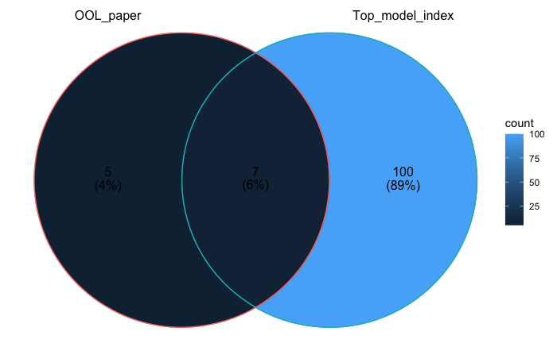

```r
# List of features
x <- list(OOL_paper = c("CD56loCD16posNK_STAT1_IFNa",
                        #"Granulocytes",
                        "CD4Tnaive_MAPKAPK2_IFNa",
                        "ncMCs_CREB_GMCSF",
                        "CD8Tem_MAPKAPK2_unstim",
                        "pDCs_STAT1_IFNa",
                        "Bcells_MAPKAPK2_LPS",
                        "CD4Tem_MAPKAPK2_unstim",
                        "CD8Tem_MAPKAPK2_IFNa",
                        #"Bcells",
                        "CD4Tem_NFkB_IL246",
                        "CD4Tcm_IkB_unstim",
                        #"mDCs_STAT6_IFNa",
                        "pDCs_STAT6_IFNa",
                        #"mDCs_MAPKAPK2_unstim",
                        "pDCs_MAPKAPK2_unstim"),
          Top_model_index = feature.index %>%
                                dplyr::filter(model_index > 0.) %>%
                                dplyr::select(feature) %>%
                                unlist() %>%
                                as.character())

ggVennDiagram(x, label_alpha = 0)
```

## Patients clustering

Here we want to cluster the patients of the OOL data the 4 patients from the drug assay study.

```r
clusters
```

```
[[1]]
 [1] "99"  "98"  "91"  "87"  "83"  "57"  "56"  "52"  "51"  "50"  "45"  "44"  "43"  "42"  "41"  "40"  "35"  "34"  "33"  "28"  "26"  "27"  "25"  "21"  "19"  "17"  "16"  "14"  "7"
[30] "6"   "5"   "3"   "1"   "100"

[[2]]
[1] "32" "24" "22"

[[3]]
[1] "93" "86" "74" "63" "36" "18" "8"  "12" "73"

[[4]]
[1] "75" "72" "68" "67" "54" "65" "55"
```

```r
# Filter out variables with variance not equal to zero
filtered_data <- data_points %>% select_if(~sd(., na.rm = TRUE) != 0)

# Separating cluster number from actual coordinates
patient_clusters  <- data_points$cluster %>% as.character()
data <- dplyr::select(filtered_data, -cluster)

# Imputing missing values and determining the optimal number of principal components to represent our data
nb <- estim_ncpPCA(data,method.cv = "Kfold", verbose = FALSE)
```

## Visualization of simulated drug effect

All simulated predictions

```r
all.simulated.predictions <- c()
for (i in 1:length(prdC)){
  all.simulated.predictions <- rbind(all.simulated.predictions, prdC[[i]]$median.simulated.TTL, prdC[[i]]$individual.simulated.TTL)
}
colnames(all.simulated.predictions) <- c("drug", "sampleID", "centroid", "dose", "TTL.prediction")
```

Function plotting the distributions of the differences between estimated TTL and estimated TTL with simulated effect of the 15 drugs at concentration c_k (with c_k in {1, 2, 3, 4}) clustered around centroid.val (with centroid.val in {1, 2, 3, 4, median}).

```r
plot_delay_distribution <- function(c_k, centroid.val="median", EGA.inf=0, EGA.sup=40){
  # Filtering the samples corresponding to EGA between EGA.inf and EGA.sup days
  filter.ID <- subset(read_csv(paste0(OOL_path, "/Preprocessed Data/EGA_OOL.csv"), show_col_types = FALSE),
                      EGA >= EGA.inf & EGA <= EGA.sup,
                      select = ID)$ID

  # Getting the simulated predictions
  drug_dose_simulated_predictions <- dplyr::filter(all.simulated.predictions, (centroid==centroid.val)&(dose==10^(c_k-1))) %>%
                                      pivot_wider(names_from = drug, values_from = TTL.prediction) %>% column_to_rownames("sampleID") %>%
                                      dplyr::select(-c(centroid, dose))

  # Getting the row numbers of the predictions corresponding to simulated.data
  row_numbers <- which(data$ID %in% filter.ID)

  # TTL predictions
  TTL.predictions <- matrix(list_preds[[model.name]][row_numbers],
                            nrow = length(row_numbers),
                            ncol = dim(drug_dose_simulated_predictions)[2],
                            dimnames = list(filter.ID, colnames(drug_dose_simulated_predictions)))

  # Difference between the TTL predictions and the TTL predictions with simulated drug effect
  drug.effect.on.predictions <- - (drug_dose_simulated_predictions[filter.ID,] - TTL.predictions[filter.ID,])

  # Looking at the distributions of the drug simulated effect in term of days on the TTL prediction
  plot.data <- as.data.frame(drug.effect.on.predictions)

  # Reshape data into long format
  plot.data_long <- gather(plot.data, key = "drug", value = "value")

  # Plot distributions
  p <- ggplot(plot.data_long, aes(x = value, fill = drug)) +
    geom_density(alpha = 0.5) +
    xlab("Delay (in days)") +
    geom_vline(xintercept = 0, linetype = "dashed") +
    ggtitle(paste0("Dose ", 10^(c_k-1))) +
    theme_minimal()
  plot(p)
}

# Creating a new directory
if (!file.exists(paste0(my_path, "/Plots/Drug effect delay distributions"))){dir.create(paste0(my_path, "/Plots/Drug effect delay distributions"))}

# Plotting all the combinations of plots possible
for (centroid.val in unique(all.simulated.predictions$centroid)){
  pdf(paste0(my_path, "/Plots/Drug effect delay distributions/Delay distribution for ", ifelse(centroid.val=="median","median effect", paste("cluster",centroid.val)), ".pdf"))
  for (c_k in 1:4){
    plot_delay_distribution(c_k, centroid.val, 38, 38.3)
  }
  dev.off()
}
```

Function plotting the distributions of the differences between estimated TTL and estimated TTL with simulated effect for a given drug and its concentration c_k (with c_k in {1, 2, 3, 4}) across the four clusters.

```r
plot_delay_distribution_across_clusters <- function(target_drug, c_k, EGA.inf=0, EGA.sup=40){
  # Filtering the samples corresponding to EGA between EGA.inf and EGA.sup days
  filter.ID <- subset(read_csv(paste0(OOL_path, "/Preprocessed Data/EGA_OOL.csv"), show_col_types = FALSE),
                      EGA >= EGA.inf & EGA <= EGA.sup,
                      select = ID)$ID

  # Getting the simulated predictions
  drug_dose_simulated_predictions <- dplyr::filter(all.simulated.predictions, (drug==target_drug)&(dose==10^(c_k-1))) %>%
                                      pivot_wider(names_from = centroid, values_from = TTL.prediction) %>% column_to_rownames("sampleID") %>%
                                      dplyr::select(-c(drug, dose, median))

  # Getting the row numbers of the predictions corresponding to simulated.data
  row_numbers <- which(data$ID %in% filter.ID)

  # TTL predictions
  TTL.predictions <- matrix(list_preds[[model.name]][row_numbers],
                            nrow = length(row_numbers),
                            ncol = dim(drug_dose_simulated_predictions)[2],
                            dimnames = list(filter.ID, colnames(drug_dose_simulated_predictions)))

  # Difference between the TTL predictions and the TTL predictions with simulated drug effect
  drug.effect.on.predictions <- - (drug_dose_simulated_predictions[filter.ID,] - TTL.predictions[filter.ID,])

  # Looking at the distributions of the drug simulated effect in term of days on the TTL prediction
  plot.data <- as.data.frame(drug.effect.on.predictions)

  # Reshape data into long format
  plot.data_long <- gather(plot.data, key = "centroid", value = "value")

  # Plot distributions
  p <- ggplot(plot.data_long, aes(x = value, fill = centroid)) +
    geom_density(alpha = 0.5) +
    xlab("Delay (in days)") +
    geom_vline(xintercept = 0, linetype = "dashed") +
    ggtitle(paste0("Dose ", 10^(c_k-1))) +
    scale_x_continuous(limits=c(-15, 15)) +
    theme_minimal()
  plot(p)
}

# Creating a new directory
if (!file.exists(paste0(my_path, "/Plots/Drug effect delay distributions"))){dir.create(paste0(my_path, "/Plots/Drug effect delay distributions"))}

# Plotting the best drug concentration effect on the different clusters
target_drug = "Progesterone"
c_k = 2

pdf(paste0(my_path, "/Plots/Drug effect delay distributions/Delay distribution for ", target_drug, " dose=", 10^(c_k-1), " across 4 clusters.pdf"))
plot_delay_distribution_across_clusters(target_drug, c_k, 30, 40)
dev.off()
```